# Simple Linear Regression

Vladislav Kargin

November 2022

## Linear regression by direct calculations

Using a chemical procedure called differential pulse polarography, a chemist measured the peak current generated (in microamperes, $\mu$A) when solutions containing different amounts of nickel (measured in parts per billion, ppb) are added to different portions of the same buffer.

First, let us input the response and explanatory variables and let us create a scatter plot to see if there is a dependence:

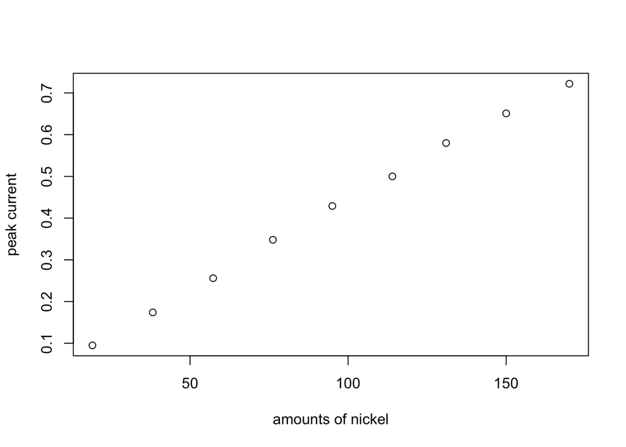

```r
y = c(0.095,0.174,0.256,0.348,0.429,0.500,0.580,0.651,0.722)

x = c(19.1,38.2,57.3,76.2,95,114,131,150,170)

plot(x,y,ylab="peak current",xlab="amounts of nickel")
```

Now let us calculate the estimate of $\beta_1$

```r
n = length(x)
Sxx = sum((x - mean(x))^2)
Sxy = sum((x - mean(x))*(y - mean(y)))
beta1hat = Sxy/Sxx
print(Sxx)
```

```
## [1] 21066.82
```

```r
print(Sxy)
```

```
## [1] 88.80003
```

```r
print(beta1hat)
```

```
## [1] 0.004215161
```

Now, suppose we want to test the null hypothesis that $\beta_1 = 0$.

In order to do the test we need to estimate $\sigma$. For this purpose we calculate SSE. (We also illustrate another formula for SSE: Syy - Sxy^2/Sxx)

```r
SSE = sum((y - mean(y) - beta1hat *(x - mean(x)))^2)
SSE
```

```
## [1] 0.0004911382
```

```r
Syy = sum((y - mean(y))^2)
SSE = Syy - Sxy^2/Sxx
SSE
```

```
## [1] 0.0004911382
```

```r
sigma_hat = sqrt(SSE/(n - 2))
sigma_hat
```

```
## [1] 0.008376312
```

Now we can construct the test statistic

```r
T = (beta1hat - 0)/(sigma_hat/sqrt(Sxx))
T
```

```
## [1] 73.04001
```

Here it is obvious that null hypothesis can be rejected. Otherwise, we would need to calculate a p-value by using the cumulative distribution function of the test statistic.

```r
2* pt(T,n-2,lower.tail = F)
```

```
## [1] 2.371798e-11
```

## Linear regression via call to “lm” function

All these calculations have been preprogrammed in R, though.

```r
model.lm = lm(y~x)
smry = summary(model.lm)
print(smry)
```

```
##
## Call:
## lm(formula = y ~ x)
##
## Residuals:
##        Min         1Q     Median         3Q        Max
## -0.0133264 -0.0042777 -0.0000231  0.0080557  0.0098107
##
## Coefficients:
##              Estimate Std. Error t value Pr(>|t|)
## (Intercept) 1.875e-02  6.129e-03   3.059   0.0183 *
## x           4.215e-03  5.771e-05  73.040 2.37e-11 ***
## ---
## Signif. codes:  0 '***' 0.001 '**' 0.01 '*' 0.05 '.' 0.1 ' ' 1
##
## Residual standard error: 0.008376 on 7 degrees of freedom
## Multiple R-squared:  0.9987, Adjusted R-squared:  0.9985
## F-statistic:  5335 on 1 and 7 DF,  p-value: 2.372e-11
```

```r
SSE_check = sum((y - fitted(model.lm))^2)
SSE
```

```
## [1] 0.0004911382
```

```r
SSE_check
```

```
## [1] 0.0004911382
```

You ran also see that R calculated the t-statistic and p-values needed to test the hypothesis that a parameter is equal to zero. If the p-value less that $5\%$, R denotes this parameter with a star, if it is smaller than $1\%$, then the parameter gets 2 stars and our slope parameter got 3 stars as very highly significant.

(Note that if you wanted to test one sided hypothesis, then you would need to divide the p-value by 2.)

If we want to test if $\beta_1$ is equal to some other value, for example 0.004, we can either extract the coefficients and standard errors from the regression output, calculate the statistic and p-value

```r
z = smry$coefficients
z
```

```
##                Estimate   Std. Error   t value     Pr(>|t|)
## (Intercept) 0.018749024 0.0061285265  3.059304 1.834140e-02
## x           0.004215161 0.0000577103 73.040008 2.371798e-11
```

```r
T = (z[2,1] - 0.004)/z[2,2]
T
```

```
## [1] 3.728291
```

```r
2*pt(T, n-2, lower.tail = F)
```

```
## [1] 0.007375271
```

Alternatively, we can re-parameterize the model and run the linear regression again:

```r
summary(lm((y - 0.004*x ~ x)))
```

```
##
## Call:
## lm(formula = (y - 0.004 * x ~ x))
##
## Residuals:
##        Min         1Q     Median         3Q        Max
## -0.0133264 -0.0042777 -0.0000231  0.0080557  0.0098107
##
## Coefficients:
##              Estimate Std. Error t value Pr(>|t|)
## (Intercept) 1.875e-02  6.129e-03   3.059  0.01834 *
## x           2.152e-04  5.771e-05   3.728  0.00738 **
## ---
## Signif. codes:  0 '***' 0.001 '**' 0.01 '*' 0.05 '.' 0.1 ' ' 1
##
## Residual standard error: 0.008376 on 7 degrees of freedom
## Multiple R-squared:  0.6651, Adjusted R-squared:  0.6172
## F-statistic:  13.9 on 1 and 7 DF,  p-value: 0.007375
```

Note that this gives the same p-value $0.00738$